# Predicting the Properties of Galaxies in the GOODS-North Field from Multiwavelength Photometry

Cherie Hua

Fall 2020

# Introduction

The Cosmic Assembly Near-Infrared Deep Extragalactic Legacy Survey (CANDELS) is a program that generates catalogs of distant galaxies observed by the Hubble Space Telescope in five small sky fields, including the so-called GOODS-North field. Astrophysicists use these catalogs to test theories of galaxy evolution. They contain measurements of brightness at a number of wavelengths as well as estimates of galaxy masses made using computationally intensive physics-based codes. A key question is whether one can directly estimate galaxy masses from the brightness data alone.

# Data

The data consist of two measurements of sky coordinates and 13 measurements of brightness at different wavelengths. The response variable that we are trying to predict is galaxy stellar mass, in units of solar masses. There are 13,359 measurements of each variable.

The predictors are described below.

| Predictor | Description |
| --- | --- |
| RA, DEC | Celestial longitude and latitude of galaxy |
| KPNO_U_FLUX | Brightness of galaxy as observed in the U band at Kitt Peak National Observatory |
| LBC_U_FLUX | … in the U’ band at the Large Binocular Telescope |
| ACS_(F435W,F606W,F775W,F814W,F850LP)_FLUX | … at five different wavelengths (0.435 microns, etc.) using Hubble’s Advanced Camera for Surveys |
| WFC3_(F105W,F125W,F140W,F160W)_FLUX | … at four different wavelengths (1.05 microns, etc.) using Hubble’s Wide-Field Camera |
| MOIRCS_K_FLUX | … in the K band at the Subaru Telescope |
| CFHT_Ks_FLUX | … in the Ks band at the Canada-France-Hawaii Telescope |

These predictors will be used to predict the log-base-10 of the estimated galaxy stellar mass, in units of solar masses.

# EDA

First, we will plot each variable against the response variable. Since FLUX data are right-skewed, we will apply a log transformation.

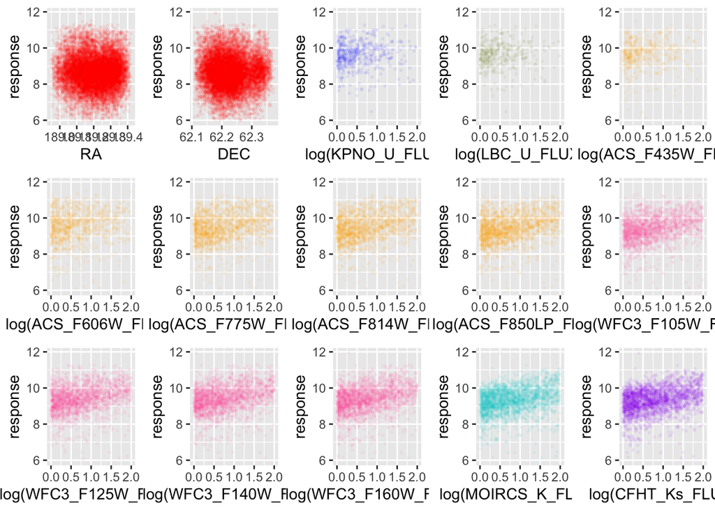

Other than RA and DEC, which seem randomly distributed, the graphs seem pretty similar. Thus, we will exclude RA and DEC from our pairs plot.

We will first compare the ACS_FLUX data variables against each other.

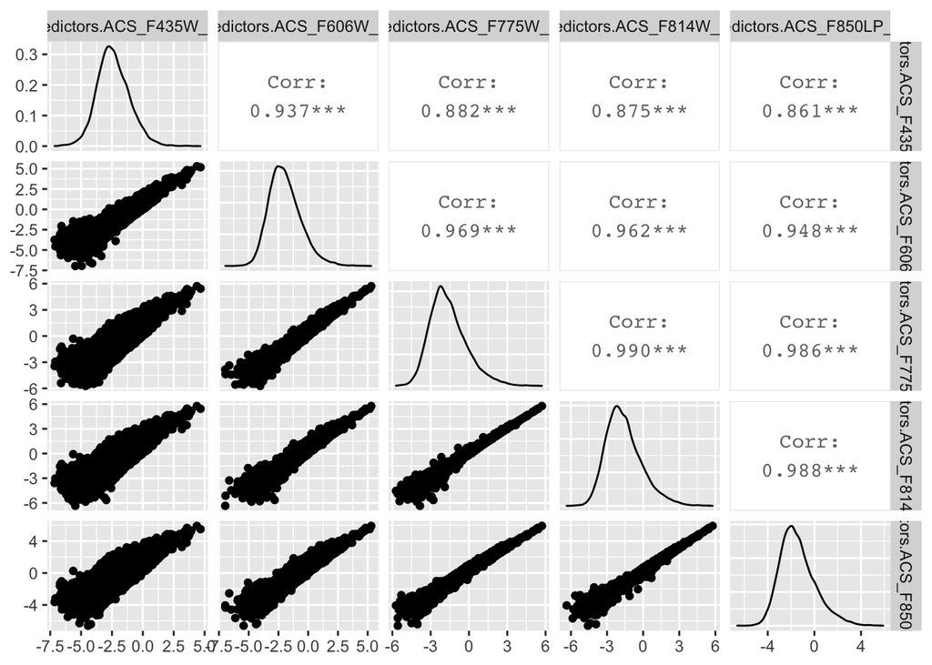

```r
ggpairs(data.frame(log(predictors$ACS_F435W_FLUX), log(predictors$ACS_F606W_FLUX), log(predictors$ACS_F775W_FLUX), log(predictors$ACS_F814W_FLUX), log(predictors$ACS_F850LP_FLUX)))
```

The ACS data collected at different wavelengths appear highly positively correlated.

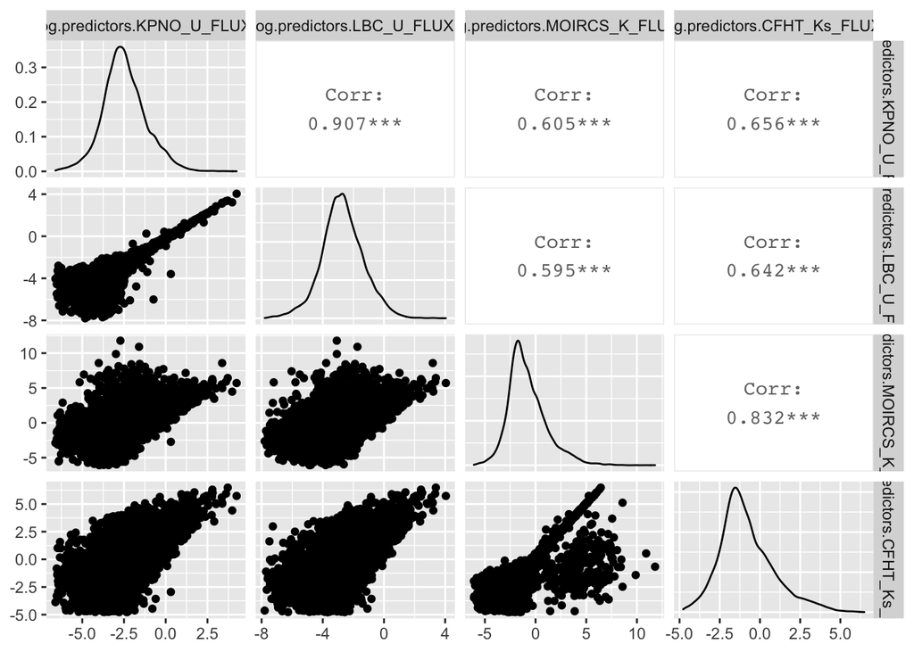

```r
ggpairs(data.frame(log(predictors$KPNO_U_FLUX), log(predictors$LBC_U_FLUX), log(predictors$MOIRCS_K_FLUX), log(predictors$CFHT_Ks_FLUX)))
```

Other than KPNO_U_FLUX vs LBC_U_FLUX, the data do not seem to be highly correlated.

Finally, to examine the WFC_FLUX variables:

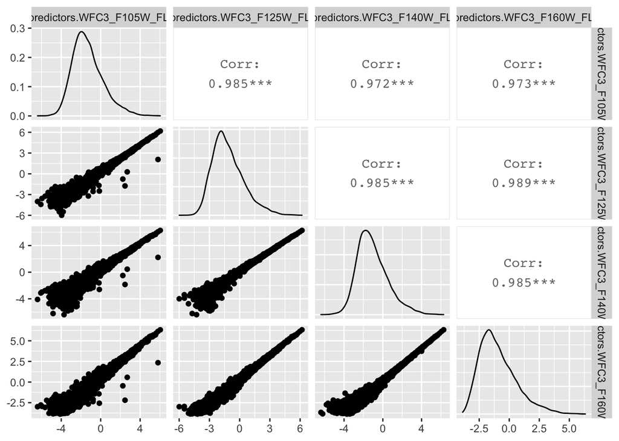

```r
suppressWarnings(ggpairs(data.frame(log(predictors$WFC3_F105W_FLUX), log(predictors$WFC3_F125W_FLUX), log(predictors$WFC3_F140W_FLUX), log(predictors$WFC3_F160W_FLUX))))
```

The WFC data collected at different wavelengths appear highly positively correlated.

To analyze the response variable, we will use a histogram:

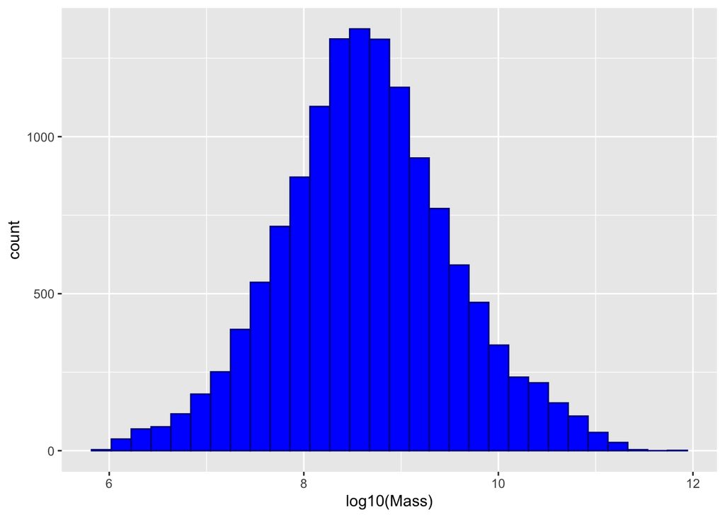

```r
ggplot(data.frame(response), mapping = aes(x = response)) + geom_histogram(fill = "blue", color = "darkBlue", bins = 30) + xlab("log10(Mass)")
```

The response variable appears to be symmetric, with no outliers.

### Principal Components Analysis (PCA)

We will perform PCA to determine the most important variables for analysis. PCA can reduce the number of dimensions while retaining as much information as possible.

```r
pca.out = prcomp(predictors, scale = TRUE)
pca.var = pca.out$sdev^2
pca.pve = pca.var/sum(pca.var)
data.frame("PC Variable" = 1:15, "Proportion of Data Explained" = round(pca.pve, 3))
```

```
##    PC.Variable Proportion.of.Data.Explained
## 1            1                        0.713
## 2            2                        0.100
## 3            3                        0.073
## 4            4                        0.067
## 5            5                        0.034
## 6            6                        0.007
## 7            7                        0.005
## 8            8                        0.001
## 9            9                        0.001
## 10          10                        0.000
## 11          11                        0.000
## 12          12                        0.000
## 13          13                        0.000
## 14          14                        0.000
## 15          15                        0.000
```

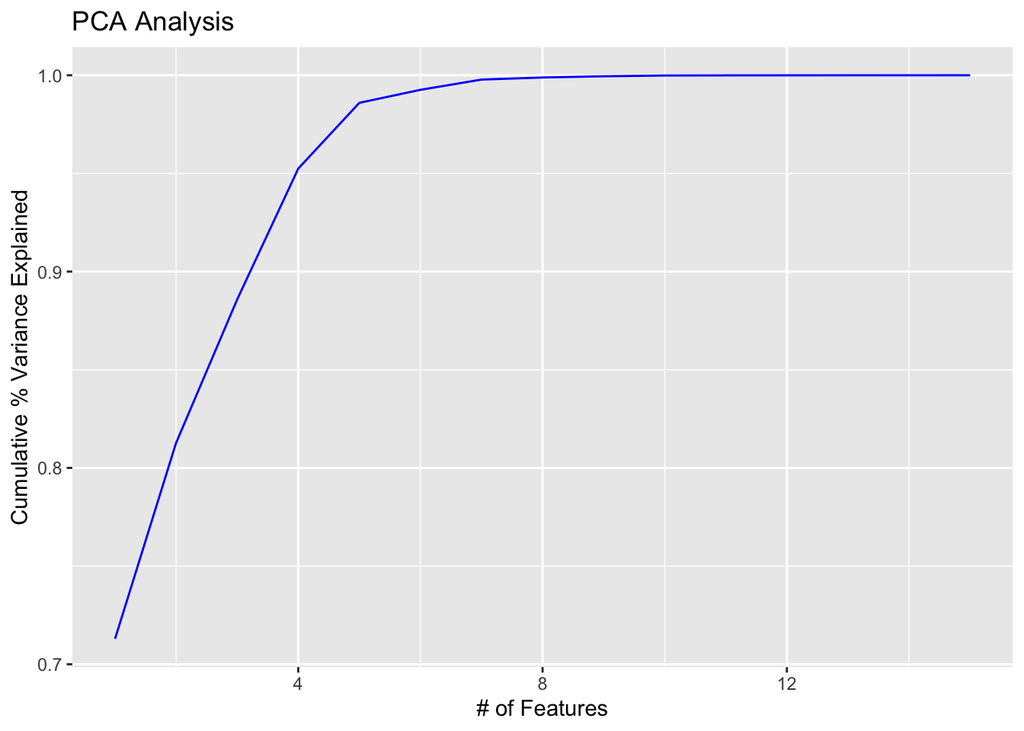

```r
pve.sum = cumsum(pca.pve)
pve.df = data.frame("range" = 1:15, "sum" = pve.sum)
ggplot(pve.df, mapping = aes(range, sum)) + geom_line(color = "blue") + xlab("# of Features") + ylab("Cumulative % Variance Explained") + ggtitle("PCA Analysis")
```

# Initial Regression Analyses

We will use 70% of the 13359 measurements as training data, and the rest as testing data.

Below, we apply a log transformation to every predictor except RA and DEC, as they are not right skewed. Then we will use vif to create a dataset with the most important variables.:

```r
set.seed(13981)

predictors = log(abs(predictors))
predictors$RA = 10^abs(predictors$RA)
predictors$DEC = 10^abs(predictors$DEC)

#find which variables to keep
THRESHOLD = 10
pred.vif = predictors
istop = 0
while ( istop == 0 ) {
  lm.out = lm(response~.,data=pred.vif)
  v = vif(lm.out)
  if ( max(v) > THRESHOLD ) {
    pred.vif = pred.vif[,-which.max(v)]
  } else {
    istop = 1
  }
}
print(v)
```

```
##              RA             DEC     KPNO_U_FLUX      LBC_U_FLUX  ACS_F435W_FLUX
##        1.338062        1.332221        6.619541        7.192156        8.225377
## WFC3_F105W_FLUX   MOIRCS_K_FLUX    CFHT_Ks_FLUX
##        9.904187        3.679522        6.476651
```

```r
#8 predictors after vif
predictors.vif = subset(predictors, select = c(RA, DEC, KPNO_U_FLUX, LBC_U_FLUX, ACS_F435W_FLUX, WFC3_F105W_FLUX, MOIRCS_K_FLUX, CFHT_Ks_FLUX))
```

Afterwards, we split the data for the full set of predictors and the vif-selected predictors.

```r
dt = sort(sample(nrow(predictors), nrow(predictors)*0.7))
pred.train = predictors[dt,]
pred.test = predictors[-dt,]
pred.train.vif = predictors.vif[dt,]
pred.test.vif = predictors.vif[-dt,]
resp.train = response[dt]
resp.test = response[-dt]
data.train = data.frame(cbind(pred.train, resp.train))
```

First, we will try linear regression.

```r
#linear regression
set.seed(5294)
lm.train = lm(resp.train ~ ., data = pred.train)
summary(lm.train)
```

```
##
## Call:
## lm(formula = resp.train ~ ., data = pred.train)
##
## Residuals:
##     Min      1Q  Median      3Q     Max
## -3.2751 -0.1986  0.0722  0.2551  2.8399
##
## Coefficients:
##                   Estimate Std. Error t value Pr(>|t|)
## (Intercept)     -5.162e+00  4.093e+00  -1.261   0.2073
## RA               4.414e-05  2.677e-05   1.649   0.0992 .
## DEC              4.358e-04  2.058e-04   2.117   0.0342 *
## KPNO_U_FLUX     -1.766e-02  1.010e-02  -1.749   0.0803 .
## LBC_U_FLUX      -2.084e-01  9.945e-03 -20.952  < 2e-16 ***
## ACS_F435W_FLUX   2.914e-01  1.519e-02  19.178  < 2e-16 ***
## ACS_F606W_FLUX  -3.684e-03  2.237e-02  -0.165   0.8692
## ACS_F775W_FLUX  -3.496e-01  3.085e-02 -11.333  < 2e-16 ***
## ACS_F814W_FLUX  -2.453e-01  2.964e-02  -8.276  < 2e-16 ***
## ACS_F850LP_FLUX -3.035e-01  3.036e-02  -9.996  < 2e-16 ***
## WFC3_F105W_FLUX -1.300e-01  2.213e-02  -5.871 4.47e-09 ***
## WFC3_F125W_FLUX  2.250e-01  3.357e-02   6.703 2.17e-11 ***
## WFC3_F140W_FLUX  1.178e-01  2.087e-02   5.643 1.72e-08 ***
## WFC3_F160W_FLUX  7.896e-01  2.742e-02  28.794  < 2e-16 ***
## MOIRCS_K_FLUX    5.856e-02  5.300e-03  11.049  < 2e-16 ***
## CFHT_Ks_FLUX     1.251e-01  8.826e-03  14.171  < 2e-16 ***
## ---
## Signif. codes:  0 '***' 0.001 '**' 0.01 '*' 0.05 '.' 0.1 ' ' 1
##
## Residual standard error: 0.4883 on 9335 degrees of freedom
## Multiple R-squared:  0.6981, Adjusted R-squared:  0.6976
## F-statistic:  1439 on 15 and 9335 DF,  p-value: < 2.2e-16
```

```r
vif(lm.train)
```

```
##              RA             DEC     KPNO_U_FLUX      LBC_U_FLUX  ACS_F435W_FLUX
##        1.339678        1.336663        6.592715        7.359558       15.401070
##  ACS_F606W_FLUX  ACS_F775W_FLUX  ACS_F814W_FLUX ACS_F850LP_FLUX WFC3_F105W_FLUX
##       35.925359       78.409753       75.868504       83.129528       45.940811
## WFC3_F125W_FLUX WFC3_F140W_FLUX WFC3_F160W_FLUX   MOIRCS_K_FLUX    CFHT_Ks_FLUX
##      105.499002       42.556465       68.107056        3.917754        8.590640
```

```r
lm.preds = predict(lm.train, newdata = pred.test)
lm.mse = mean((resp.test - lm.preds)^2)
lm.mse
```

```
## [1] 0.2407809
```

Next, we will try linear regresssion with the vif()-reduced set of predictors.

```r
#linear regression with vif
set.seed(5294)
lm.train = lm(resp.train ~ ., data=pred.train.vif)
summary(lm.train)
```

```
##
## Call:
## lm(formula = resp.train ~ ., data = pred.train.vif)
##
## Residuals:
##     Min      1Q  Median      3Q     Max
## -3.4606 -0.3074  0.0873  0.3943  2.6404
##
## Coefficients:
##                   Estimate Std. Error t value Pr(>|t|)
## (Intercept)     -3.439e+00  4.954e+00  -0.694    0.488
## RA               4.771e-05  3.241e-05   1.472    0.141
## DEC              2.858e-04  2.489e-04   1.148    0.251
## KPNO_U_FLUX     -7.054e-02  1.219e-02  -5.789 7.32e-09 ***
## LBC_U_FLUX      -1.867e-01  1.173e-02 -15.912  < 2e-16 ***
## ACS_F435W_FLUX   2.267e-01  1.331e-02  17.031  < 2e-16 ***
## WFC3_F105W_FLUX -9.386e-02  1.234e-02  -7.604 3.16e-14 ***
## MOIRCS_K_FLUX    1.254e-01  6.222e-03  20.150  < 2e-16 ***
## CFHT_Ks_FLUX     3.398e-01  9.183e-03  37.007  < 2e-16 ***
## ---
## Signif. codes:  0 '***' 0.001 '**' 0.01 '*' 0.05 '.' 0.1 ' ' 1
##
## Residual standard error: 0.5918 on 9342 degrees of freedom
## Multiple R-squared:  0.5563, Adjusted R-squared:  0.556
## F-statistic:  1464 on 8 and 9342 DF,  p-value: < 2.2e-16
```

```r
vif(lm.train)
```

```
##              RA             DEC     KPNO_U_FLUX      LBC_U_FLUX  ACS_F435W_FLUX
##        1.336484        1.330970        6.538611        6.976782        8.050908
## WFC3_F105W_FLUX   MOIRCS_K_FLUX    CFHT_Ks_FLUX
##        9.731180        3.677371        6.333796
```

```r
lm.preds = predict(lm.train, newdata = pred.test)
lm.mse = mean((resp.test - lm.preds)^2)
lm.mse
```

```
## [1] 0.3588059
```

The adjusted-R^2 value is 0.5560, indicating that this fit is reasonably accurate. The MSE is 0.3588.

Next we will try glm with BIC and predict using the best model.

```r
#glm
set.seed(49287)
glm.all <- bestglm(na.omit(data.train), IC = "BIC")
glm.all
```

```
## BIC
## BICq equivalent for q in (0.27944552887432, 0.953256441933201)
## Best Model:
##                      Estimate   Std. Error     t value      Pr(>|t|)
## (Intercept)      0.4335923260 2.4149413533   0.1795457  8.575131e-01
## DEC              0.0005933412 0.0001786651   3.3209680  9.004995e-04
## LBC_U_FLUX      -0.2185231038 0.0081947331 -26.6662868 4.750170e-151
## ACS_F435W_FLUX   0.2852720215 0.0116927292  24.3973855 1.684981e-127
## ACS_F775W_FLUX  -0.3543846294 0.0278506452 -12.7244675  8.728746e-37
## ACS_F814W_FLUX  -0.2454087929 0.0290907078  -8.4359856  3.772774e-17
## ACS_F850LP_FLUX -0.3037095082 0.0301152372 -10.0849117  8.526821e-24
## WFC3_F105W_FLUX -0.1303898591 0.0220805157  -5.9051999  3.645162e-09
## WFC3_F125W_FLUX  0.2290872788 0.0333300961   6.8732859  6.675599e-12
## WFC3_F140W_FLUX  0.1182696242 0.0208625945   5.6689797  1.479192e-08
## WFC3_F160W_FLUX  0.7880373247 0.0271084549  29.0697986 6.161185e-178
## MOIRCS_K_FLUX    0.0579300827 0.0052927597  10.9451563  1.032532e-27
## CFHT_Ks_FLUX     0.1247975684 0.0088126349  14.1612094  4.651966e-45
```

```r
glm.all.preds = predict(glm.all$BestModel, newdata = pred.test)
glm.all.mse = mean((resp.test - glm.all.preds)^2)
glm.all.mse
```

```
## [1] 0.2408989
```

The MSE is 0.2409.

Next we will try glm with BIC using the vif-reduced predictors, and predict using the best model.

```r
#glm with vif
set.seed(28947)
data.train.vif = cbind(pred.train.vif, resp.train)
glm.vif <- bestglm(data.train.vif, IC = "BIC")

glm.vif.preds = predict(glm.vif$BestModel, newdata = pred.test)
glm.vif.mse = mean((resp.test[1:length(glm.vif.preds)] - glm.vif.preds)^2)
glm.vif.mse
```

```
## [1] 0.3596344
```

The MSE is 0.3596.

Next we will try lasso regression.

```r
#lasso
set.seed(2948)
x.train = model.matrix(~., pred.train)
x.test = model.matrix(~., pred.test)
lasso.mass = cv.glmnet(x.train, resp.train, alpha=1)

lasso.mass.pred = predict(lasso.mass, lambda=lasso.mass$lambda.min, x.test)
lasso.mass.mse = mean((predict(lasso.mass, lambda=lasso.mass$lambda.min, x.test) - resp.test)^2)
lasso.mass.mse
```

```
## [1] 0.248191
```

The MSE is 0.2482.

Next we will try lasso with the vif-reduced predictors.

```r
#lasso with vif
set.seed(0384)
x.train = model.matrix(~., pred.train.vif)
x.test = model.matrix(~., pred.test.vif)
lasso.vif = cv.glmnet(x.train, resp.train, alpha=1)

lasso.vif.pred = predict(lasso.vif, lambda=lasso.vif$lambda.min, x.test)
lasso.vif.mse = mean((predict(lasso.vif, lambda=lasso.vif$lambda.min, x.test) - resp.test)^2)
lasso.vif.mse
```

```
## [1] 0.3634891
```

The MSE is 0.3635.

Next we will try ridge regression.

```r
#ridge
set.seed(39827)
x.train = model.matrix(~., pred.train)
x.test = model.matrix(~., pred.test)
ridge.mass = cv.glmnet(x.train, resp.train, alpha=0)

ridge.predict = predict(ridge.mass, lambda=ridge.mass$lambda.min, x.test)
ridge.mass.mse = mean((predict(ridge.mass, lambda=ridge.mass$lambda.min, x.test) - resp.test)^2)
ridge.mass.mse
```

```
## [1] 0.2797337
```

The MSE is 0.2797.

Next we will try ridge regression with the vif-reduced predictors.

```r
#ridge with vif
set.seed(1285)
x.train = model.matrix(~., pred.train.vif)
x.test = model.matrix(~., pred.test.vif)
ridge.mass = cv.glmnet(x.train, resp.train, alpha=0)

ridge.predict = predict(ridge.mass, lambda=ridge.mass$lambda.min, x.test)
ridge.mass.mse = mean((predict(ridge.mass, lambda=ridge.mass$lambda.min, x.test) - resp.test)^2)
ridge.mass.mse
```

```
## [1] 0.3716655
```

The MSE is 0.3717.

Next we will try random forest.

```r
#random forest
set.seed(4810)
library(randomForest)
rf <- randomForest(formula = resp.train ~ ., data = pred.train, importance = TRUE)
yhat.rf = predict(rf, newdata = pred.test)
rf.mse = mean((yhat.rf - resp.test)^2)
rf.mse
```

```
## [1] 0.1732337
```

Next we will try k-nearest neighbors.

```r
#k-nearest neighbors
set.seed(8103)
library(FNN)
k.max <- 45
mse.k <- vector("double", length = k.max)
for (i in 1:k.max) {
  reg <- knn.reg(pred.train, y = resp.train, test = pred.test, k = i, algorithm="brute")
  mse.k[i] <- mean((reg$pred - resp.test)^2)
}

min(mse.k)
```

```
## [1] 0.5243667
```

The MSE is 0.5244.

[output not shown]

| vif()-Reduced Model | MSE |
| --- | --- |
| vif()-reduced linear regression | 0.3588 |
| vif()-reduced bestglm | 0.3596 |
| vif()-reduced lasso regression | 0.3635 |
| vif()-reduced ridge regression | 0.3717 |

Based on our tables, it is clear to see a prediction-inference tradeoff. We sacrifice an average of about a 50% increase in MSE if we were to pursue inference.

According to our table of MSE’s, the best model is the random forest model as it is closest to 0.

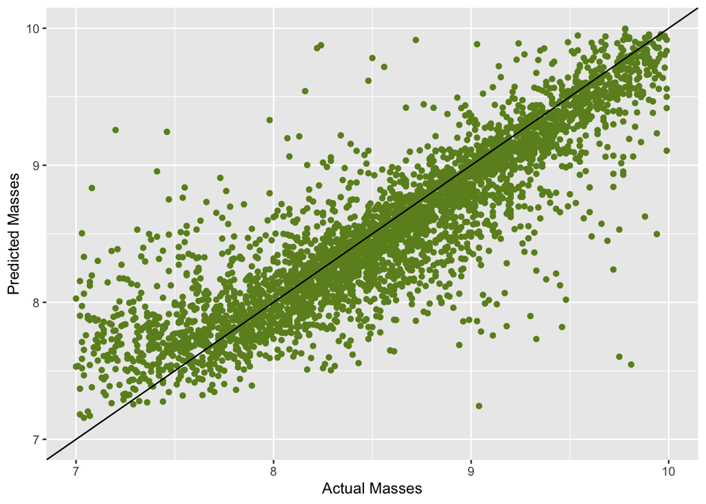

```r
ggplot() + geom_point(aes(x = resp.test, y = yhat.rf), color = "olivedrab") + geom_abline() + xlab("Actual Masses") + ylab("Predicted Masses") + xlim(7, 10) + ylim(7, 10)
```

The relationship between predicted and actual masses looks relatively positively linear. This indicates that our random forest model is fairly accurate.

# Conclusion